# Untitled

KE Lotterhos

10/10/2019

setwd(“~/Documents/GitHub/2017OAExp_Oysters/markdown_files/compareGonadMantle”)

```r
packages_needed <- c("scales", "biomartr", "rio", "tidyverse", "googledrive","data.table"
                     )

for (i in 1:length(packages_needed)){
  if(!(packages_needed[i] %in% installed.packages())){install.packages(packages_needed[i])}
}


for (i in 1:length(packages_needed)){
  library( packages_needed[i], character.only = TRUE)
}
```

```r
bioc_packages_needed <- c("karyoploteR", "Biostrings", "biomaRt")

if(length(bioc_packages_needed)>0){
  if (!requireNamespace("BiocManager", quietly = TRUE))
    install.packages("BiocManager")
  for (i in 1:length(packages_needed)){
     if(!(bioc_packages_needed[i] %in% installed.packages())){BiocManager::install(packages_needed[i])
     }
  }
}


for (i in 1:length(bioc_packages_needed)){
  library(bioc_packages_needed[i], character.only = TRUE)
}
```

ftp://ftp.ncbi.nlm.nih.gov/genomes/all/GCF/002/022/765/GCF_002022765.2_C_virginica-3.0/GCF_002022765.2_C_virginica-3.0_genomic.gff.gz

```r
if(!file.exists("_ncbi_downloads")){
  gff.file <- getGFF(organism="Crassostrea virginica", gunzip=TRUE)
}
#gff.file <-"./ref_C_virginica-3.0_top_level.gff3"
gff.file <- "_ncbi_downloads/annotation/Crassostrea_virginica_genomic_refseq.gff"

header.lines <- readLines(gff.file)

#The lines with the standard chromosomes start with "##sequence-region ".
#Select them.
ll <- header.lines[grepl(header.lines, pattern = "##sequence-region ")]


#split them by space, and create a data.frame
gg <- data.frame(do.call(rbind, strsplit(ll, split = " ")))
gg[,3] <- as.numeric(as.character(gg[,3]))
gg[,4] <- as.numeric(as.character(gg[,4]))

CV.genome <- toGRanges(gg[,c(2,3,4)])
```

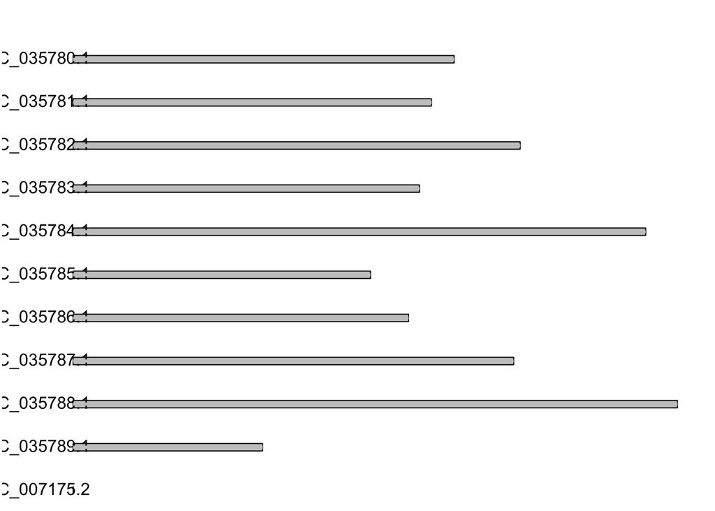

```r
kp <- plotKaryotype(genome=CV.genome)
kpAddCytobandsAsLine(kp)
```

```r
#features_df <- read_gff(gff.file)
#head(features_df)
features <- rtracklayer::import(gff.file)
head(features)
```

```
## GRanges object with 6 ranges and 46 metadata columns:
##          seqnames      ranges strand |   source     type     score
##             <Rle>   <IRanges>  <Rle> | <factor> <factor> <numeric>
##   [1] NC_035780.1  1-65668440      + |   RefSeq   region      <NA>
##   [2] NC_035780.1 13578-14594      + |   Gnomon     gene      <NA>
##   [3] NC_035780.1 13578-14594      + |   Gnomon  lnc_RNA      <NA>
##   [4] NC_035780.1 13578-13603      + |   Gnomon     exon      <NA>
##   [5] NC_035780.1 14237-14290      + |   Gnomon     exon      <NA>
##   [6] NC_035780.1 14557-14594      + |   Gnomon     exon      <NA>
##           phase          ID                                  Dbxref
##       <integer> <character>                         <CharacterList>
##   [1]      <NA>         id0                              taxon:6565
##   [2]      <NA>       gene0                        GeneID:111116054
##   [3]      <NA>        rna0 GeneID:111116054,Genbank:XR_002636969.1
##   [4]      <NA>         id1 GeneID:111116054,Genbank:XR_002636969.1
```

[output cut: 92 more lines]

```r
seqnames(features)
```

```
## factor-Rle of length 1513272 with 11 runs
##   Lengths:      144044      173152      229143 ...       32979          77
##   Values : NC_035780.1 NC_035781.1 NC_035782.1 ... NC_035789.1 NC_007175.2
## Levels(11): NC_007175.2 NC_035780.1 ... NC_035788.1 NC_035789.1
```

```r
chrs <- as.character(seqnames(features)@values[1:10])

levels(features$type)
```

```
##  [1] "region"     "gene"       "lnc_RNA"    "exon"       "mRNA"
##  [6] "CDS"        "pseudogene" "tRNA"       "transcript" "cDNA_match"
## [11] "rRNA"
```

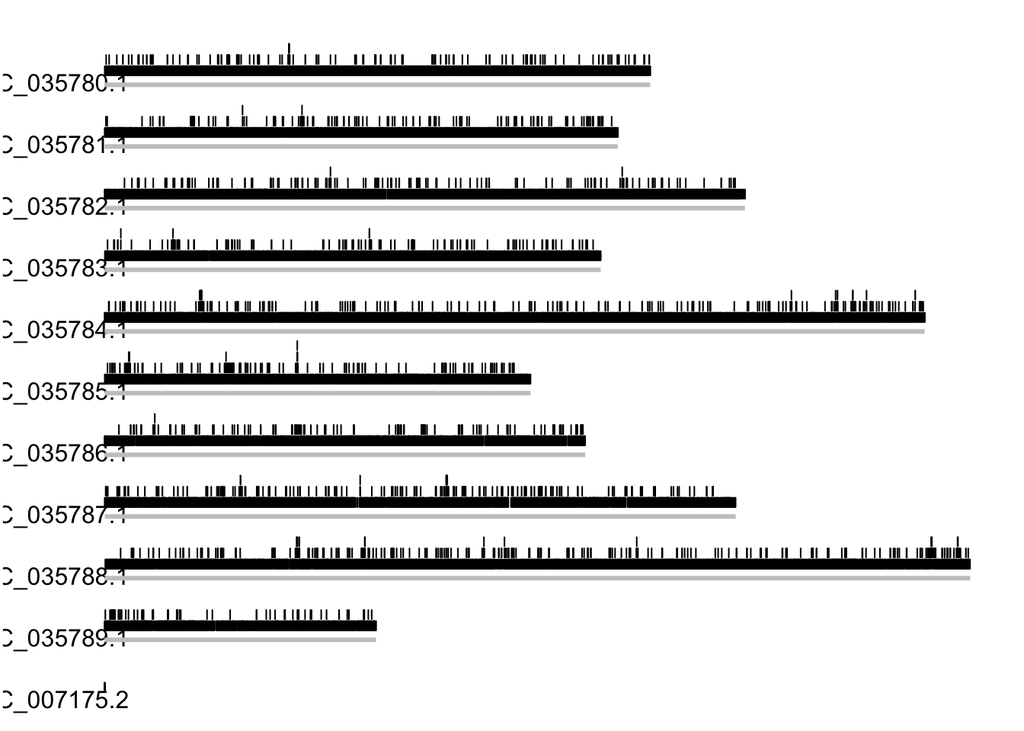

```r
genes <- features[features$type=="gene" ,]
exons <- features[features$type=="exon",]

#gff.file <-"./HSP.gff3"
#features <- import(gff.file)
#HSP <- features[features$type=="exon"]
#HSP <- reduce(HSP)

exons.sc <-IRanges::reduce(exons)
genes.sc <-IRanges::reduce(genes)

kp <- plotKaryotype(genome=CV.genome, ideogram.plotter = NULL)
kpAddCytobandsAsLine(kp)
kpPlotRegions(kp, data=genes)
```

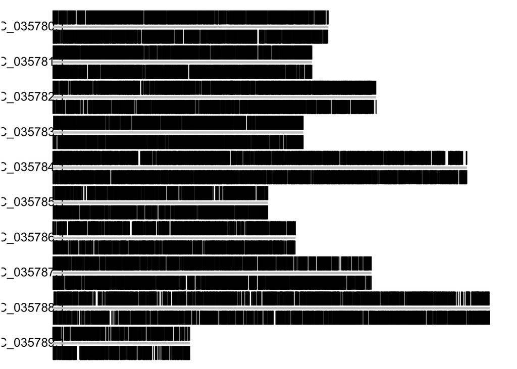

```r
kp <- plotKaryotype(genome=CV.genome, ideogram.plotter = NULL, plot.type=2, chromosomes = chrs)
kpAddCytobandsAsLine(kp)
kpPlotRegions(kp, data=genes[strand(genes)=="+"], avoid.overlapping = FALSE)
kpPlotRegions(kp, data=genes[strand(genes)=="-"], avoid.overlapping = FALSE, data.panel=2)
```

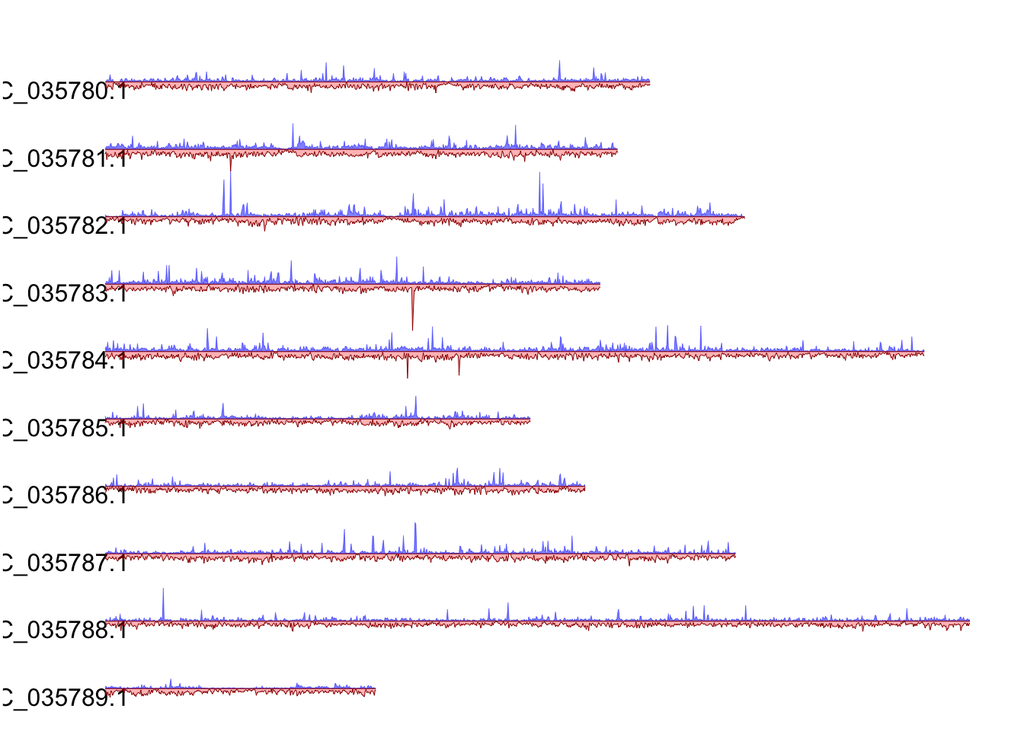

```r
kp <- plotKaryotype(genome=CV.genome[1:10], ideogram.plotter = NULL, chromosomes=chrs)
#kpAddCytobandsAsLine(kp)
kpPlotDensity(kp, data=exons,window.size = 100000, col=adjustcolor("blue", 0.5), lwd=0.5, border=adjustcolor("blue", 0.5), r0=0, r1=1)
kpPlotDensity(kp, data=genes,window.size = 100000, col=adjustcolor("red", 0.3), lwd=0.5, data.panel=2, r0=0, r1=-1)
```

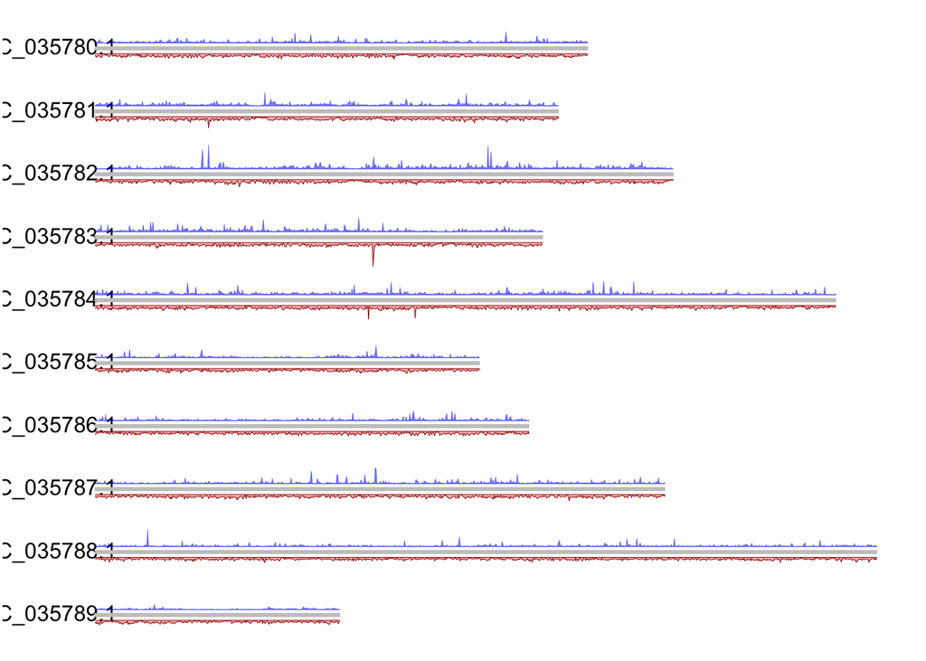

```r
kp <- plotKaryotype(genome=CV.genome[1:10], ideogram.plotter = NULL, chromosomes=chrs, plot.type=2)
kpAddCytobandsAsLine(kp)
kpPlotDensity(kp, data=exons,window.size = 100000, col=adjustcolor("blue", 0.5), lwd=0.5, border=adjustcolor("blue", 0.5), data.panel=1)
kpPlotDensity(kp, data=genes,window.size = 100000, col=adjustcolor("red", 0.3), lwd=0.5, data.panel=2) #this should plot on the bottom, but doesn't seem to work
```

The first three required BED fields are:

chrom - The name of the chromosome (e.g. chr3, chrY, chr2_random) or scaffold (e.g. scaffold10671). chromStart - The starting position of the feature in the chromosome or scaffold. The first base in a chromosome is numbered 0. chromEnd - Ending position

### Load methylation data for mantle

Data from Alan Downey-Wall 2017 exposure experiment

`CG_unstranded_BetaMatrix.RData` represents the beta values for each individual at all potential CpG sites based on the oyster genome. In this file i destranded paired CpG cytosines prior to calculating the beta value. The two important complimentary files to this one are `CG_unstranded_summaryTable.RData` for relevant CpG position information and `CG_unstranded_TotalCountMatrix.RData` for the coverage.

These files contain all cpgs identified by Bismarck using the oyster genome. It has not been filtered.

```r
list.files("~/Google Drive/LotterhosLab/2017-2020-Oyster OA Epigenetics/2017_CV_AdultExposureExp/Data/DNAm/Data/")
```

```
##  [1] "CG_stranded_BetaMatrix.RData"
##  [2] "CG_stranded_methylCountMatrix.RData"
##  [3] "CG_stranded_summaryTable.RData"
##  [4] "CG_stranded_TotalCountMatrix.RData"
##  [5] "CG_stranded_unmethylCountMatrix.RData"
##  [6] "CG_unstranded_BetaMatrix.RData"
##  [7] "CG_unstranded_methylCountMatrix.RData"
##  [8] "CG_unstranded_summaryTable.RData"
##  [9] "CG_unstranded_TotalCountMatrix.RData"
## [10] "CG_unstranded_unmethylCountMatrix.RData"
## [11] "filtered_countMatrices"
## [12] "Icon\r"
## [13] "positiveStrandContribution_Hist.png"
## [14] "positiveStrandEffectOnBeta.png"
```

```r
mantle <- readRDS("~/Google Drive/LotterhosLab/2017-2020-Oyster OA Epigenetics/2017_CV_AdultExposureExp/Data/DNAm/Data/CG_unstranded_BetaMatrix.RData")
colnames(mantle) <- paste0("s", colnames(mantle))
head(mantle)
```

```
##                 s17005 s17007 s17013 s17019 s17069 s17070 s17072
## NC_007175.2_49       0      0 0.0000      0      0      0      0
## NC_007175.2_51       0      0 0.0000      0      0      0      0
## NC_007175.2_88       0      0 0.0000      0      0      0      0
## NC_007175.2_147      0      0 0.0625      0      0      0      0
## NC_007175.2_193      0      0 0.0000      0      0      0      0
## NC_007175.2_246      0      0 0.0000      0      0      0      0
##                     s17079 s17090     s17094 s17099 s17108 s17122
## NC_007175.2_49  0.00000000      0 0.00000000      0      0      0
## NC_007175.2_51  0.00000000      0 0.00000000      0      0      0
## NC_007175.2_88  0.00000000      0 0.00000000      0      0      0
## NC_007175.2_147 0.00000000      0 0.00000000      0      0      0
## NC_007175.2_193 0.00000000      0 0.00000000      0      0      0
## NC_007175.2_246 0.07142857      0 0.07692308      0      0      0
##                     s17130     s17142 s17145 s17162 s17174 s17176 s17178
## NC_007175.2_49  0.00000000 0.00000000 0.0000      0      0      0      0
## NC_007175.2_51  0.00000000 0.00000000 0.0000      0      0      0      0
## NC_007175.2_88  0.03333333 0.00000000 0.0000      0      0      0      0
## NC_007175.2_147 0.00000000 0.02941176 0.0000      0      0      0      0
## NC_007175.2_193 0.00000000 0.00000000 0.0625      0      0      0      0
## NC_007175.2_246 0.00000000 0.06250000 0.0000      0      0      0      0
##                 s17181 s17203     s17211     s17213
## NC_007175.2_49       0      0 0.00000000 0.00000000
## NC_007175.2_51       0      0 0.33333333 0.07692308
## NC_007175.2_88       0      0 0.00000000 0.00000000
## NC_007175.2_147      0      0 0.05555556 0.02631579
## NC_007175.2_193      0      0 0.00000000 0.00000000
## NC_007175.2_246      0      0 0.00000000 0.00000000
```

```r
mantle1 <- as.data.frame(mantle) # takes afew seconds
#mantle1 <- data.table(mantle) # gives error with dplyr functions
head(mantle1)
```

```
##                 s17005 s17007 s17013 s17019 s17069 s17070 s17072
## NC_007175.2_49       0      0 0.0000      0      0      0      0
## NC_007175.2_51       0      0 0.0000      0      0      0      0
## NC_007175.2_88       0      0 0.0000      0      0      0      0
## NC_007175.2_147      0      0 0.0625      0      0      0      0
## NC_007175.2_193      0      0 0.0000      0      0      0      0
## NC_007175.2_246      0      0 0.0000      0      0      0      0
##                     s17079 s17090     s17094 s17099 s17108 s17122
## NC_007175.2_49  0.00000000      0 0.00000000      0      0      0
## NC_007175.2_51  0.00000000      0 0.00000000      0      0      0
## NC_007175.2_88  0.00000000      0 0.00000000      0      0      0
## NC_007175.2_147 0.00000000      0 0.00000000      0      0      0
## NC_007175.2_193 0.00000000      0 0.00000000      0      0      0
## NC_007175.2_246 0.07142857      0 0.07692308      0      0      0
##                     s17130     s17142 s17145 s17162 s17174 s17176 s17178
## NC_007175.2_49  0.00000000 0.00000000 0.0000      0      0      0      0
## NC_007175.2_51  0.00000000 0.00000000 0.0000      0      0      0      0
## NC_007175.2_88  0.03333333 0.00000000 0.0000      0      0      0      0
## NC_007175.2_147 0.00000000 0.02941176 0.0000      0      0      0      0
## NC_007175.2_193 0.00000000 0.00000000 0.0625      0      0      0      0
## NC_007175.2_246 0.00000000 0.06250000 0.0000      0      0      0      0
##                 s17181 s17203     s17211     s17213
## NC_007175.2_49       0      0 0.00000000 0.00000000
## NC_007175.2_51       0      0 0.33333333 0.07692308
## NC_007175.2_88       0      0 0.00000000 0.00000000
## NC_007175.2_147      0      0 0.05555556 0.02631579
## NC_007175.2_193      0      0 0.00000000 0.00000000
## NC_007175.2_246      0      0 0.00000000 0.00000000
```

```r
mantle2 <- mantle1 %>% dplyr::select(-c(s17099)) %>% dplyr::mutate(betamean = rowMeans(mantle1))
mantle2$pos <- rownames(mantle)
head(mantle2)
```

```
##   s17005 s17007 s17013 s17019 s17069 s17070 s17072     s17079 s17090
## 1      0      0 0.0000      0      0      0      0 0.00000000      0
## 2      0      0 0.0000      0      0      0      0 0.00000000      0
## 3      0      0 0.0000      0      0      0      0 0.00000000      0
## 4      0      0 0.0625      0      0      0      0 0.00000000      0
## 5      0      0 0.0000      0      0      0      0 0.00000000      0
## 6      0      0 0.0000      0      0      0      0 0.07142857      0
##       s17094 s17108 s17122     s17130     s17142 s17145 s17162 s17174
## 1 0.00000000      0      0 0.00000000 0.00000000 0.0000      0      0
## 2 0.00000000      0      0 0.00000000 0.00000000 0.0000      0      0
## 3 0.00000000      0      0 0.03333333 0.00000000 0.0000      0      0
## 4 0.00000000      0      0 0.00000000 0.02941176 0.0000      0      0
## 5 0.00000000      0      0 0.00000000 0.00000000 0.0625      0      0
## 6 0.07692308      0      0 0.00000000 0.06250000 0.0000      0      0
##   s17176 s17178 s17181 s17203     s17211     s17213    betamean
## 1      0      0      0      0 0.00000000 0.00000000 0.000000000
## 2      0      0      0      0 0.33333333 0.07692308 0.017094017
## 3      0      0      0      0 0.00000000 0.00000000 0.001388889
## 4      0      0      0      0 0.05555556 0.02631579 0.007240963
## 5      0      0      0      0 0.00000000 0.00000000 0.002604167
## 6      0      0      0      0 0.00000000 0.00000000 0.008785485
##               pos
## 1  NC_007175.2_49
## 2  NC_007175.2_51
## 3  NC_007175.2_88
## 4 NC_007175.2_147
## 5 NC_007175.2_193
## 6 NC_007175.2_246
```

```r
rm(mantle, mantle1)

mantle_pos <- readRDS("~/Google Drive/LotterhosLab/2017-2020-Oyster OA Epigenetics/2017_CV_AdultExposureExp/Data/DNAm/Data/CG_unstranded_summaryTable.RData")
names(mantle_pos)[1:3] <- c("chrom", "chromStart", "chromEnd")
  # bedfile naming system - not sure yet if this is necessary to work with ranges
mantle_pos$pos <- paste(mantle_pos$chrom, mantle_pos$chromStart, sep="_")
head(mantle_pos)
```

```
##         chrom chromStart chromEnd C_motif Tri_motif             pos
## 1 NC_007175.2         49       50      CG       CGC  NC_007175.2_49
## 2 NC_007175.2         51       52      CG       CGG  NC_007175.2_51
## 3 NC_007175.2         88       89      CG       CGT  NC_007175.2_88
## 4 NC_007175.2        147      148      CG       CGG NC_007175.2_147
## 5 NC_007175.2        193      194      CG       CGC NC_007175.2_193
## 6 NC_007175.2        246      247      CG       CGC NC_007175.2_246
```

```r
mantle_counts <- readRDS("~/Google Drive/LotterhosLab/2017-2020-Oyster OA Epigenetics/2017_CV_AdultExposureExp/Data/DNAm/Data/CG_unstranded_TotalCountMatrix.RData")
head(mantle_counts)
```

```
##                 17005 17007 17013 17019 17069 17070 17072 17079 17090
## NC_007175.2_49      0     0     7     2     2     1     1     3     6
## NC_007175.2_51      0     0     7     3     2     1     1     3     6
## NC_007175.2_88      1     3    15    14     5     3    10     9    11
## NC_007175.2_147     5     2    16    15    10     5    10    14    18
## NC_007175.2_193     2     0    14     9     8     6    12    12    14
## NC_007175.2_246     5     1    13     8     5    10     8    14    14
##                 17094 17099 17108 17122 17130 17142 17145 17162 17174
## NC_007175.2_49      4     2     3     4    11    11     8     3     5
## NC_007175.2_51      4     2     3     5    10    11     7     4     5
## NC_007175.2_88      8     4    10     6    30    30    14    12    13
## NC_007175.2_147    12     6    11     5    23    34    12    14    14
## NC_007175.2_193    15     1    14     3    14    33    16    20     9
## NC_007175.2_246    13     1    13    10    23    32    14    18    14
##                 17176 17178 17181 17203 17211 17213
## NC_007175.2_49      8     7     5     6     3    11
## NC_007175.2_51      9     7     5     6     3    13
## NC_007175.2_88     26    11    12    12    13    25
## NC_007175.2_147    36    16    17    15    18    38
## NC_007175.2_193    34    21    12    13    13    26
## NC_007175.2_246    35    12    13    16     8    23
```

```r
mantle_info <- readRDS("~/Google Drive/LotterhosLab/2017-2020-Oyster OA Epigenetics/2017_CV_AdultExposureExp/Data/meta/metadata_20190811.Rdata")
head(mantle_info)
```

```
##   sample_name sample_index treatment timepoint Day D9_C D9_E D80_C D80_E
## 1    RNA17005            1       400         6  80    0    0     1     0
## 2    RNA17007            2       400         6  80    0    0     1     0
## 3    RNA17013            3       400         3   9    1    0     0     0
## 4    RNA17019            4      2800         6  80    0    0     0     1
## 5    RNA17069            5       400         3   9    1    0     0     0
## 6    RNA17070            6       400         3   9    1    0     0     0
##   shelf tank tankID population extraction_order seq_order lane
## 1     1    1      1          2               21        22    2
## 2     1    2      2          1               17        10    1
## 3     2    2      5          1               11         5    1
## 4     4    3      9          2               14        20    2
## 5     1    1      1          3                3         1    1
## 6     1    2      2          1                7        13    2
##   gw_tapestation_RINe gw_tapestation_conc read_num dry_wgtcorr
```

[output cut: 20 more lines]

```r
mantle_plot <- full_join(mantle_pos, mantle2)
head(mantle_plot)
```

```
##         chrom chromStart chromEnd C_motif Tri_motif             pos s17005
## 1 NC_007175.2         49       50      CG       CGC  NC_007175.2_49      0
## 2 NC_007175.2         51       52      CG       CGG  NC_007175.2_51      0
## 3 NC_007175.2         88       89      CG       CGT  NC_007175.2_88      0
## 4 NC_007175.2        147      148      CG       CGG NC_007175.2_147      0
## 5 NC_007175.2        193      194      CG       CGC NC_007175.2_193      0
## 6 NC_007175.2        246      247      CG       CGC NC_007175.2_246      0
##   s17007 s17013 s17019 s17069 s17070 s17072     s17079 s17090     s17094
## 1      0 0.0000      0      0      0      0 0.00000000      0 0.00000000
## 2      0 0.0000      0      0      0      0 0.00000000      0 0.00000000
## 3      0 0.0000      0      0      0      0 0.00000000      0 0.00000000
## 4      0 0.0625      0      0      0      0 0.00000000      0 0.00000000
## 5      0 0.0000      0      0      0      0 0.00000000      0 0.00000000
## 6      0 0.0000      0      0      0      0 0.07142857      0 0.07692308
##   s17108 s17122     s17130     s17142 s17145 s17162 s17174 s17176 s17178
## 1      0      0 0.00000000 0.00000000 0.0000      0      0      0      0
## 2      0      0 0.00000000 0.00000000 0.0000      0      0      0      0
## 3      0      0 0.03333333 0.00000000 0.0000      0      0      0      0
## 4      0      0 0.00000000 0.02941176 0.0000      0      0      0      0
## 5      0      0 0.00000000 0.00000000 0.0625      0      0      0      0
## 6      0      0 0.00000000 0.06250000 0.0000      0      0      0      0
##   s17181 s17203     s17211     s17213    betamean
## 1      0      0 0.00000000 0.00000000 0.000000000
## 2      0      0 0.33333333 0.07692308 0.017094017
## 3      0      0 0.00000000 0.00000000 0.001388889
## 4      0      0 0.05555556 0.02631579 0.007240963
## 5      0      0 0.00000000 0.00000000 0.002604167
## 6      0      0 0.00000000 0.00000000 0.008785485
```

```r
#kp <- plotKaryotype(genome=CV.genome[1:10], ideogram.plotter = NULL, chromosomes=chrs)
#kpAddCytobandsAsLine(kp)
# kp
# kpLines(kp, x=mantle_plot$chromStart, y=mantle_plot$betamean, data.panel = 1, chr=mantle_plot$chrom) DO NOT DO THIS - WAAAY TO MUCH INFO TO PLOT
#kpAxis(kp, data.panel=1)
```

Let’s summarize this beta data and plot it for a custom window size.

This code uses the split, apply, combine approach to produce data summaries.

For more information, check out Vince Buffalo’s Bioinformatics Book.

```r
beta_split_chrom <- split(mantle_plot$beta, mantle_plot$chrom)
str(beta_split_chrom)
```

```
## List of 11
##  $ NC_007175.2: num [1:431] 0 0.01709 0.00139 0.00724 0.0026 ...
##  $ NC_035780.1: num [1:1394962] 0.00417 0.02205 0.03475 0.00777 0.00553 ...
##  $ NC_035781.1: num [1:1237469] 0 0 0 0 0 0 0 0 0 0 ...
##  $ NC_035782.1: num [1:1568195] 0.111 0.472 0.349 0.361 0.118 ...
##  $ NC_035783.1: num [1:1200917] 0.1458 0.1458 0 0 0.0417 ...
##  $ NC_035784.1: num [1:2008680] 0.522 0.558 0.277 0.396 0.668 ...
##  $ NC_035785.1: num [1:1121671] 0.4904 0.4333 0.4132 0.0833 0 ...
##  $ NC_035786.1: num [1:1251184] 0 0 0 0 0.0417 ...
##  $ NC_035787.1: num [1:1633946] 0 0 0.0417 0 0 ...
##  $ NC_035788.1: num [1:2300335] 0.0417 0.1667 0.1368 0.1524 0.4309 ...
##  $ NC_035789.1: num [1:740913] 0 0.0208 0 0 0 ...
```

```r
beta_pos_chrom  <- split(mantle_plot$chromStart, mantle_plot$chrom)
str(beta_pos_chrom)
```

```
## List of 11
##  $ NC_007175.2: int [1:431] 49 51 88 147 193 246 257 264 266 332 ...
##  $ NC_035780.1: int [1:1394962] 29 55 76 94 104 117 135 160 210 225 ...
##  $ NC_035781.1: int [1:1237469] 631 646 794 810 909 932 935 965 1092 1369 ...
##  $ NC_035782.1: int [1:1568195] 108 169 194 310 371 394 507 516 539 678 ...
##  $ NC_035783.1: int [1:1200917] 99 113 259 273 281 294 307 414 436 453 ...
##  $ NC_035784.1: int [1:2008680] 141 155 291 313 470 611 683 834 1506 1516 ...
##  $ NC_035785.1: int [1:1121671] 218 524 557 728 1331 1404 1495 1748 2025 2055 ...
##  $ NC_035786.1: int [1:1251184] 112 118 147 157 224 273 297 337 356 417 ...
##  $ NC_035787.1: int [1:1633946] 44 53 160 229 240 255 393 517 542 666 ...
##  $ NC_035788.1: int [1:2300335] 7 31 62 71 101 137 143 192 195 204 ...
##  $ NC_035789.1: int [1:740913] 75 77 96 104 112 122 180 183 291 300 ...
```

```r
summ_beta <- function(beta, pos, window1=10^5){
  bins <- cut(pos, breaks=seq(1, max(pos), by = window1))
  #beta_split <- split(beta, bins)
  out <- do.call(rbind, lapply(split(beta, bins), summary))
  out2 <- as.data.frame(out)
  out2$mid <- seq(window1/2, (max(pos)-window1/2), by = window1)
  out2$window <- rownames(out)
  return(out2)
}
```

Make a plot with Mantle Methylation on the top and exon density on the bottom

```r
png("Mantle2018Top_ExonDensityBottom.png", width=12, height=8, units="in", res=400)
  kp <- plotKaryotype(genome=CV.genome, ideogram.plotter = NULL, chromosomes=chrs,
                      plot.type=2)
  kpAddCytobandsAsLine(kp)

  for (i in 2:length(beta_split_chrom)){
    a<-
  summ_beta(beta_split_chrom[[i]], beta_pos_chrom[[i]])
  head(a)
  kpLines(kp, x=a$mid, y=a$"1st Qu.", data.panel = 1, chr=names(beta_split_chrom[i]), col="grey")
  kpLines(kp, x=a$mid, y=a$"3rd Qu.", data.panel = 1, chr=names(beta_split_chrom[i]), col="grey")
  kpLines(kp, x=a$mid, y=a$Mean, data.panel = 1, chr=names(beta_split_chrom[i]))
  }

  kpAxis(kp, data.panel=1, labels = c("", 0.5, 1))

  kpPlotDensity(kp, data=exons,window.size = 100000, col=adjustcolor("blue", 0.5), lwd=0.5, border=adjustcolor("blue", 0.5), data.panel=2, r0=0, r1=1)
dev.off()
```

### Load methylation data for gonads

Data from Yaamini V 2016 exposure experiment

```
bedfile <- "bedfiles/2019-04-09-All-5x-CpGs.bedgraph"
if(!file.exists(bedfile)){
  dir.create("bedfiles")
  download.file("https://gannet.fish.washington.edu/spartina/2018-10-10-project-virginica-oa-Large-Files/2019-05-13-Yaamini-Virginica-Repository/analyses/2019-03-18-Characterizing-CpG-Methylation/2019-04-09-All-5x-CpGs.bedgraph", "bedfiles/2019-04-09-All-5x-CpGs.bedgraph")
}

# gonads <- rtracklayer::import(bedfile) # error

system("head bedfiles/2019-04-09-All-5x-CpGs.bedgraph")
gonads <- read.table("bedfiles/2019-04-09-All-5x-CpGs.bedgraph")

head(gonads)
```

coverage.1 <- import.bed(“./Total_EC.2c.bed”) test.cov <- toGRanges(coverage.1)

coverage.2 <- import.bed(“./m4q4sc.bed”) test.cov2 <- toGRanges(coverage.2)

kpPlotCoverage(kp, data=test.cov)

kp <- plotKaryotype(genome=CV.genome, ideogram.plotter = NULL,plot.type=2, chromosomes = “NC_035780.1”) kpAddCytobandsAsLine(kp) kpPlotDensity(kp, data=exons.sc,window.size = 1000, chromosomes=“NC_035780.1”) #kpPoints(kp, chr=“NC_007175.2”, data=test.cov, y=score, data.panel = 2) kpPlotCoverage(kp, data=test.cov, data.panel=2,chromosomes=“NC_035780.1”)

kp <- plotKaryotype(genome=CV.genome, ideogram.plotter = NULL,plot.type=2, chromosomes = “NC_035780.1”) kpAddCytobandsAsLine(kp) kpPlotDensity(kp, data=exons,window.size = 1000000, chr=“NC_035780.1”) kpPlotDensity(kp, data=test.cov,window.size=1000000, chr=“NC_035780.1”, data.panel=2)

EC_2.bam <-“./ECI_2.F.bam”

kpAddChromosomeNumbers <- function(karyoplot, …){ karyoplot$beginKpPlot() on.exit(karyoplot$endKpPlot()) bb <- getChromosomeNamesBoundingBox(karyoplot) chr.labels <- seq(1,length(karyoplot$chromosomes)) chr.labels <- paste("Chr ",chr.labels,sep="") x <- (bb$x0 + bb$x1)/2 y <- (bb$y0 + bb$y1)/2 graphics::text(x = x, y = y, labels = chr.labels, …) invisible(karyoplot) }

cbPalette <- c(“#009E73”,“#D55E00”,“#56B4E9”, “#0072B2”,“#E69F00”, “#999999”,“#F0E442” , “#CC79A7”)

pie(rep(1, length(cbPalette)), labels = sprintf(“%d (%s)”, seq_along(cbPalette), cbPalette), col = alpha(cbPalette,0.9)) coverage.1 <- import.bed(“./Total_EC.2c.bed”) test.cov <- toGRanges(coverage.1)

coverage.2 <- import.bed(“./m4q4sc.bed”) test.cov2 <- toGRanges(coverage.2)

kp <- plotKaryotype(genome=CV.genome, ideogram.plotter = NULL, plot.type = 3, chromosomes=“NC_035785.1”)

png(filename=“kary1new.png”, type=“cairo”,units=“px”, width=5600, height=3000, res=300, bg=“transparent”) kp <- plotKaryotype(genome=CV.genome, ideogram.plotter = NULL, plot.type = 2, chromosomes=c(“NC_035780.1”,“NC_035781.1”,“NC_035782.1”,“NC_035783.1”,“NC_035784.1”,“NC_035785.1”,“NC_035786.1”,“NC_035787.1”,“NC_035788.1”,“NC_035789.1”),labels.plotter = kpAddChromosomeNumbers) kp$plot.params$chromosome.height=1 kp$plot.params$ideogramheight <-1 kp$plot.params$data1inmargin <- -10 kp$plot.params$data2inmargin <-30 kp$plot.params$topmargin <-0 kp$plot.params$bottommargin <-0

kpAddCytobandsAsLine(kp, lwd=5) kpAddBaseNumbers(kp) #kpPlotRegions(kp, data=exons.sc) #kpPlotRegions(kp,data=HSP) #kpPlotDensity(kp, data=HSP, col = “red”, data.panel=1,window.size = 100) #kpPlotDensity(kp, data=exons.sc,window.size = 100000) kpPlotDensity(kp, data=test.cov,window.size=100000, col=alpha(cbPalette[4],0.9),data.panel=1, ymax=150000) kpPlotDensity(kp, data=test.cov2,window.size = 100000, col=alpha(cbPalette[2],0.9),data.panel=2, ymax=40000, r1=0.9) dev.off()

png(filename=“kary.black.png”, type=“cairo”,units=“px”, width=5600, height=3000, res=300, bg=“transparent”) kp <- plotKaryotype(genome=CV.genome, ideogram.plotter = NULL, plot.type = 2, col=“white”, chromosomes=c(“NC_035780.1”,“NC_035781.1”,“NC_035782.1”,“NC_035783.1”,“NC_035784.1”,“NC_035785.1”,“NC_035786.1”,“NC_035787.1”,“NC_035788.1”,“NC_035789.1”),labels.plotter = kpAddChromosomeNumbers) kp$plot.params$chromosome.height=1 kp$plot.params$ideogramheight <-1 kp$plot.params$data1inmargin <- -10 kp$plot.params$data2inmargin <-30 kp$plot.params$topmargin <-0 kp$plot.params$bottommargin <-0

kpAddCytobandsAsLine(kp, lwd=5) kpAddBaseNumbers(kp, col=“white”) #dev.off() #kpPlotRegions(kp, data=exons.sc) #kpPlotRegions(kp,data=HSP) #kpPlotDensity(kp, data=HSP, col = “red”, data.panel=1,window.size = 100) #kpPlotDensity(kp, data=exons.sc,window.size = 100000, col=alpha(cbPalette[1],0.9), border=“white”) #dev.off() kpPlotDensity(kp, data=test.cov,window.size=100000, col=alpha(cbPalette[4],0.9),border=“white”,data.panel=2, ymax=30000) #kpPlotDensity(kp, data=test.cov2,window.size = 100000, col=“red”,data.panel=1, ymax=40000, r1=0.9)

dev.off()

kp <- plotKaryotype(genome=CV.genome, ideogram.plotter = NULL, plot.type = 3, chromosomes=“NC_035785.1”)

png(filename=“kary1.black.png”, type=“cairo”,units=“px”, width=5600, height=3000, res=300, bg=“transparent”) kp <- plotKaryotype(genome=CV.genome, ideogram.plotter = NULL, plot.type = 2, col=“white”, chromosomes=c(“NC_035780.1”,“NC_035781.1”,“NC_035782.1”,“NC_035783.1”,“NC_035784.1”,“NC_035785.1”,“NC_035786.1”,“NC_035787.1”,“NC_035788.1”,“NC_035789.1”),labels.plotter = kpAddChromosomeNumbers) kp$plot.params$chromosome.height=1 kp$plot.params$ideogramheight <-1 kp$plot.params$data1inmargin <- -10 kp$plot.params$data2inmargin <-30 kp$plot.params$topmargin <-0 kp$plot.params$bottommargin <-0

kpAddCytobandsAsLine(kp, lwd=5) kpAddBaseNumbers(kp, col=“white”) #dev.off() #kpPlotRegions(kp, data=exons.sc) #kpPlotRegions(kp,data=HSP) #kpPlotDensity(kp, data=HSP, col = “red”, data.panel=1,window.size = 100) #kpPlotDensity(kp, data=exons.sc,window.size = 100000) kpPlotDensity(kp, data=test.cov2,window.size = 100000, col=alpha(cbPalette[2],0.9),data.panel=1, border=“white”,ymax=40000, r1=0.9) #dev.off() kpPlotDensity(kp, data=test.cov,window.size=100000, col=alpha(cbPalette[4],0.9),data.panel=2, border=“white”,ymax=30000) dev.off()

png(filename=“karynew.png”, type=“cairo”,units=“px”, width=5600, height=3000, res=300, bg=“transparent”) kp <- plotKaryotype(genome=CV.genome, ideogram.plotter = NULL, plot.type = 2, chromosomes=c(“NC_035780.1”,“NC_035781.1”,“NC_035782.1”,“NC_035783.1”,“NC_035784.1”,“NC_035785.1”,“NC_035786.1”,“NC_035787.1”,“NC_035788.1”,“NC_035789.1”),labels.plotter = kpAddChromosomeNumbers) kp$plot.params$chromosome.height=1 kp$plot.params$ideogramheight <-1 kp$plot.params$data1inmargin <- -10 kp$plot.params$data2inmargin <-30 kp$plot.params$topmargin <-0 kp$plot.params$bottommargin <-0

kpAddCytobandsAsLine(kp, lwd=5) kpAddBaseNumbers(kp) #kpPlotRegions(kp, data=exons.sc) #kpPlotRegions(kp,data=HSP) #kpPlotDensity(kp, data=HSP, col = “red”, data.panel=1,window.size = 100) kpPlotDensity(kp, data=exons.sc,window.size = 100000, col=alpha(cbPalette[1],0.9)) kpPlotDensity(kp, data=test.cov,window.size=100000, col=alpha(cbPalette[4],0.9),data.panel=2, ymax=150000) #kpPlotDensity(kp, data=test.cov2,window.size = 100000, col=“red”,data.panel=1, ymax=40000, r1=0.9)

dev.off()

png(filename=“karynewblack.png”, type=“cairo”,units=“px”, width=5600, height=3000, res=300, bg=“transparent”) kp <- plotKaryotype(genome=CV.genome, ideogram.plotter = NULL, plot.type = 2, chromosomes=c(“NC_035780.1”,“NC_035781.1”,“NC_035782.1”,“NC_035783.1”,“NC_035784.1”,“NC_035785.1”,“NC_035786.1”,“NC_035787.1”,“NC_035788.1”,“NC_035789.1”),labels.plotter = kpAddChromosomeNumbers,col=“white”) kp$plot.params$chromosome.height=1 kp$plot.params$ideogramheight <-1 kp$plot.params$data1inmargin <- -30 kp$plot.params$data2inmargin <-10 kp$plot.params$topmargin <-0 kp$plot.params$bottommargin <-0

kpAddCytobandsAsLine(kp, lwd=5) kpAddBaseNumbers(kp, col=“white”) #kpPlotRegions(kp, data=exons.sc) #kpPlotRegions(kp,data=HSP) #kpPlotDensity(kp, data=HSP, col = “red”, data.panel=1,window.size = 100) kpPlotDensity(kp, data=test.cov,window.size = 100000, col=alpha(cbPalette[4],0.9),border=“grey”,ymax=150000) kpPlotDensity(kp, data=test.cov2,window.size=100000, col=alpha(cbPalette[2],0.9),data.panel=2,border=“grey”,ymax=30000, r1=0.9) #kpPlotDensity(kp, data=test.cov2,window.size = 100000, col=“red”,data.panel=1, ymax=40000, r1=0.9)

dev.off()

#kpPlotBAMDensity(kp, data = EC_2.bam, window.size = 100000, data.panel=2)